# Session 4.1 Application Activity

This R notebook accompanies the [Session 4.1 application activity](http://www.globalhealthresearch.co/modules/mod4/s4-1/) for [Global Health Research: Designs and Methods](http://www.globalhealthresearch.co/). To get started:

1. Login to your ‘virtual’ RStudio environment on Duke’s server. Go [here](https://vm-manage.oit.duke.edu/), enter your credentials, and follow the `Docker` link to the option to launch RStudio.
2. Click the “Code” button in the top right corner of this page and download the `Rmd` file.
3. Back in RStudio, go to the `Files` tab, and `Upload` the `Rmd` file you just downloaded. Then open it in RStudio.

## Setup

Since this is not a course in how to use R, we’ll do a few things in the background so you can focus on the sampling lesson (follow the link in the code chunk below if you want to examine what is happening):

- getting the data
- creating an indicator called `everMarried` that takes a value of `1` if a person is divorced, married with spouse present or absent, or widowed
- fixing some age issues
- and creating a binary indicator called `marriedBefore15` that takes a value of `1` if a person was married before the age of 15

```r
# background stuff
  source("https://tinyurl.com/yd6efrpj")
```

If this chunk ran successfully, you will have a dataframe called `dat` in your `Environment` tab.

## Examine the data

Examine the data by running the next chunk with the `head(dat)` command. This will show you the first 6 rows of the dataset. The first several variables are household-level variables, so the values are the same for every member of the household. Starting with gender, the remaining variables are measured for each individual in the household.

```r
head(dat)
```

The definitions of key variables are shown in the table below. See [this enumeration form](https://www.nappdata.org/napp-action/source_documents/enum_form_us1880a_tag.xml) to understand what citizens were asked back in 1880. [These instructions](https://www.nappdata.org/napp-action/source_documents/enum_instruct_us1880a_tag.xml) indicate how enumerators were trained to gather this information.

| Variable | Definition |
| --- | --- |
| serial | a unique identifier for households |
| numperhh | the number of people residing in each household |
| region | census region |
| statefip | state |
| urban | urban or rural classification |
| farm | farm household |
| sex | gender of person |
| age | age of person |
| marst | marital status |
| race | race |
| nativity | birthplace of self and parents |
| labforce | labor force status |

There are 1,401,478 observations in the dataset, but the official tabulation comes in slightly below this at 1,399,750. Rather than dig through the notes to determine the source of the discrepancy, we’ll go with the data file.

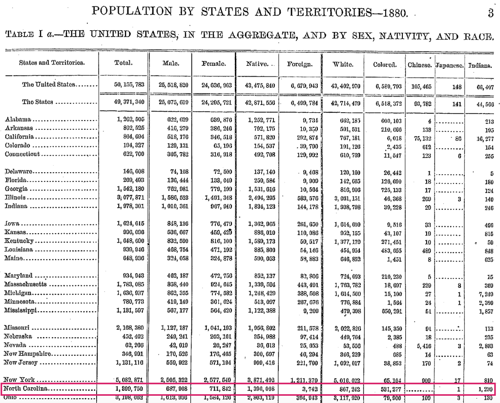

Table 1a

## Population

Before we jump into samples of the data, let’s examine the population. We created two variables in the background: `marriedBefore15` and `singleP`. Type the name of each variable into the console (one at a time) and hit enter:

- `marriedBefore15`: will return the number of children under 15 years of age who were married (or divorced/widowed) at the time the census was conducted.
- `singleP`: will return the proportion of single, never married individuals in the population of people at least 15 years old.

For the purpose of this activity, let’s take this value, 0.30, as the “truth”. This is the true proportion of adults (>=15 years) that was reported to be single, never married when the census was conducted.

## Simple Random Sampling

```r
# sample
  n <- 100
# 100 (a)
  set.seed(1)
  s100a <- dat15[sample(1:nrow(dat15), n, replace=FALSE),]
  singleCt100a <- table(s100a$marst)[names(table(s100a$marst))=="Never married/single"]
  singleP100a <- singleCt100a/n
  singleP100a
```

```
Never married/single
                 0.4
```

```r
# 100 (b)
  set.seed(2)
  s100b <- dat15[sample(1:nrow(dat15), n, replace=FALSE),]
  singleCt100b <- table(s100b$marst)[names(table(s100b$marst))=="Never married/single"]
  singleP100b <- singleCt100b/n
  singleP100b
```

```
Never married/single
                0.33
```

Now let’s draw 10,000 samples. Run the code in the block below and write down your prediction about the shape and center (mean) of the distribution of all 10,000 sample proportions. (this will take a few minutes to run!! look for the stop sign…that tells you that R is still running)

```r
# 10000 samples
  n <- 100
  singleSamples <- NULL
  for (i in 1:10000) {
    # set new seed
    set.seed(i)
    s <- dat15[sample(1:nrow(dat15), n, replace=FALSE),]
    singleCt <- table(s$marst)[names(table(s$marst))=="Never married/single"]
    singleP <- singleCt/n
    singleSamples <- c(singleSamples, singleP)
  }
```

Once you make your prediction, run the next chunk and check your prediction.

```r
hist(singleSamples)
mean(singleSamples)
```

[output not shown]

## Sampling Error, Single/Never Married

Finally, let’s examine what happens to sampling error as the sample size increases. The formula for the standard error of a proportion is:

$$sqrt(p(1-p)/N)$$
Run the following code and record your results (mean proportion, standard error, margin of error, 95% confidence interval, width of confidence interval). What changed across runs and why?

### N=100

```r
# sample size
  n <- 100

# create sample
  set.seed(1)
  s <- dat15[sample(1:nrow(dat15), n, replace=FALSE),]
  singleCt <- table(s$marst)[names(table(s$marst))=="Never married/single"]
  singleP <- singleCt/n
  print(paste0("When N is ", n, ": Mean proportion=", rd3(singleP)))

# standard error and 95% confidence intervals
  se <- sqrt((singleP*(1-singleP))/n)         # standard error
  print(paste0("When N is ", n, ": Standard error=", rd3(se)))

  me95CI <- 1.96*se                           # margin of error
  print(paste0("When N is ", n, ": Margin of error=", rd3(me95CI)))

  CI95l <- singleP - me95CI                   # lower 95% CI
  print(paste0("When N is ", n, ": Lower 95% CI=", rd3(CI95l)))

  CI95u <- singleP + me95CI                   # upper 95% CI
  print(paste0("When N is ", n, ": Upper 95% CI=", rd3(CI95u)))

  widthCI <- CI95u - CI95l                    # width of CI
  print(paste0("When N is ", n, ": Width of 95% CI=", rd3(widthCI)))
```

### N=1000

```r
# sample size
  n <- 1000

# create sample
  set.seed(1)
  s <- dat15[sample(1:nrow(dat15), n, replace=FALSE),]
  singleCt <- table(s$marst)[names(table(s$marst))=="Never married/single"]
  singleP <- singleCt/n
  print(paste0("When N is ", n, ": Mean proportion=", rd3(singleP)))

# standard error and 95% confidence intervals
  se <- sqrt((singleP*(1-singleP))/n)         # standard error
  print(paste0("When N is ", n, ": Standard error=", rd3(se)))

  me95CI <- 1.96*se                           # margin of error
  print(paste0("When N is ", n, ": Margin of error=", rd3(me95CI)))

  CI95l <- singleP - me95CI                   # lower 95% CI
  print(paste0("When N is ", n, ": Lower 95% CI=", rd3(CI95l)))

  CI95u <- singleP + me95CI                   # upper 95% CI
  print(paste0("When N is ", n, ": Upper 95% CI=", rd3(CI95u)))

  widthCI <- CI95u - CI95l                    # width of CI
  print(paste0("When N is ", n, ": Width of 95% CI=", rd3(widthCI)))
```

### N=10,000

```r
# sample size
  n <- 10000

# create sample
  set.seed(1)
  s <- dat15[sample(1:nrow(dat15), n, replace=FALSE),]
  singleCt <- table(s$marst)[names(table(s$marst))=="Never married/single"]
  singleP <- singleCt/n
  print(paste0("When N is ", n, ": Mean proportion=", rd3(singleP)))

# standard error and 95% confidence intervals
  se <- sqrt((singleP*(1-singleP))/n)         # standard error
  print(paste0("When N is ", n, ": Standard error=", rd3(se)))

  me95CI <- 1.96*se                           # margin of error
  print(paste0("When N is ", n, ": Margin of error=", rd3(me95CI)))

  CI95l <- singleP - me95CI                   # lower 95% CI
  print(paste0("When N is ", n, ": Lower 95% CI=", rd3(CI95l)))

  CI95u <- singleP + me95CI                   # upper 95% CI
  print(paste0("When N is ", n, ": Upper 95% CI=", rd3(CI95u)))

  widthCI <- CI95u - CI95l                    # width of CI
  print(paste0("When N is ", n, ": Width of 95% CI=", rd3(widthCI)))
```

## Sampling Error, Age

Do the same sequence of draws for age (we’ll go back to using the entire NC population, not the age restricted one). For reference, the mean age of the 1880 NC population was 22.2.

### N=100

```r
  n <- 100

# create sample
  set.seed(1)
  s <- dat[sample(1:nrow(dat), n, replace=FALSE),]
  ageM <- mean(s$ageN)
  print(paste0("When N is ", n, ": Mean age=", rd2(ageM)))

# standard error and 95% confidence intervals
  se <- sd(s$ageN)/sqrt(n)                    # standard error
  print(paste0("When N is ", n, ": Standard error=", rd2(se)))

  me95CI <- 1.96*se                           # margin of error
  print(paste0("When N is ", n, ": Margin of error=", rd2(me95CI)))

  CI95l <- ageM - me95CI                   # lower 95% CI
  print(paste0("When N is ", n, ": Lower 95% CI=", rd2(CI95l)))

  CI95u <- ageM + me95CI                   # upper 95% CI
  print(paste0("When N is ", n, ": Upper 95% CI=", rd2(CI95u)))

  widthCI <- CI95u - CI95l                    # width of CI
  print(paste0("When N is ", n, ": Width of 95% CI=", rd2(widthCI)))
```

### N=1000

```r
  n <- 1000

# create sample
  set.seed(1)
  s <- dat[sample(1:nrow(dat), n, replace=FALSE),]
  ageM <- mean(s$ageN)
  print(paste0("When N is ", n, ": Mean age=", rd2(ageM)))

# standard error and 95% confidence intervals
  se <- sd(s$ageN)/sqrt(n)                    # standard error
  print(paste0("When N is ", n, ": Standard error=", rd2(se)))

  me95CI <- 1.96*se                           # margin of error
  print(paste0("When N is ", n, ": Margin of error=", rd2(me95CI)))

  CI95l <- ageM - me95CI                   # lower 95% CI
  print(paste0("When N is ", n, ": Lower 95% CI=", rd2(CI95l)))

  CI95u <- ageM + me95CI                   # upper 95% CI
  print(paste0("When N is ", n, ": Upper 95% CI=", rd2(CI95u)))

  widthCI <- CI95u - CI95l                    # width of CI
  print(paste0("When N is ", n, ": Width of 95% CI=", rd2(widthCI)))
```

### N=10000

```r
  n <- 10000

# create sample
  set.seed(1)
  s <- dat[sample(1:nrow(dat), n, replace=FALSE),]
  ageM <- mean(s$ageN)
  print(paste0("When N is ", n, ": Mean age=", rd2(ageM)))

# standard error and 95% confidence intervals
  se <- sd(s$ageN)/sqrt(n)                    # standard error
  print(paste0("When N is ", n, ": Standard error=", rd2(se)))

  me95CI <- 1.96*se                           # margin of error
  print(paste0("When N is ", n, ": Margin of error=", rd2(me95CI)))

  CI95l <- ageM - me95CI                   # lower 95% CI
  print(paste0("When N is ", n, ": Lower 95% CI=", rd2(CI95l)))

  CI95u <- ageM + me95CI                   # upper 95% CI
  print(paste0("When N is ", n, ": Upper 95% CI=", rd2(CI95u)))

  widthCI <- CI95u - CI95l                    # width of CI
  print(paste0("When N is ", n, ": Width of 95% CI=", rd2(widthCI)))
```